# W10-Dashboards Assignment

Transportation Key Metrics Dashboard

Author

Saurabh Parate

Published

May 5, 2026

# Project 1: Static Dashboard

## Project Description

This project uses monthly transportation key metrics to understand how passenger activity and other performance indicators changed over time. The goal of the static dashboard is to help the audience quickly identify long-term trends, seasonal patterns, and differences between key transportation metrics.

The dashboard is designed for users who may not have a technical background. It presents simple visual summaries that explain how transportation performance changed by month and year.

## Data Description

The dataset used for this project is `pnfs_key_metrics_long.csv`. The data is organized in long format, meaning each row represents one metric for one month.

The main variables are:

- `year`: year of the observation
- `month_num`: month number
- `month`: month abbreviation
- `date`: monthly date
- `metric_raw`: original metric name
- `metric`: cleaned metric name
- `value`: numeric value of the metric
- `source_sheet`: source year/sheet

```r
library(tidyverse)
library(scales)

data <- read.csv("pnfs_key_metrics_long.csv")

data <- data |>
  mutate(
    date = as.Date(date),
    year = as.factor(year),
    metric = as.factor(metric)
  )

head(data)
```

```
  year month_num month       date       metric_raw           metric  value
1 2021         1   Jan 2021-01-01 Total Passengers Total Passengers 151860
2 2021         2   Feb 2021-02-01 Total Passengers Total Passengers 152293
3 2021         3   Mar 2021-03-01 Total Passengers Total Passengers 259491
4 2021         4   Apr 2021-04-01 Total Passengers Total Passengers 298784
5 2021         5   May 2021-05-01 Total Passengers Total Passengers 366937
6 2021         6   Jun 2021-06-01 Total Passengers Total Passengers 431085
  source_sheet
1         2021
2         2021
3         2021
4         2021
5         2021
6         2021
```

```r
# Data summary
summary(data)
```

```
   year      month_num        month                date
 2021:72   Min.   : 1.00   Length:366         Min.   :2021-01-01
 2022:72   1st Qu.: 3.00   Class :character   1st Qu.:2022-04-01
 2023:72   Median : 6.00   Mode  :character   Median :2023-07-01
 2024:72   Mean   : 6.41                      Mean   :2023-07-02
 2025:72   3rd Qu.: 9.00                      3rd Qu.:2024-10-01
 2026: 6   Max.   :12.00                      Max.   :2026-01-01
  metric_raw                           metric       value         source_sheet
 Length:366         Freight (tons)        :61   Min.   :  2423   Min.   :2021
 Class :character   Inbound (deplaned)    :61   1st Qu.: 58914   1st Qu.:2022
 Mode  :character   Mail (tons)           :61   Median : 85710   Median :2023
                    Outbound (enplaned)   :61   Mean   :194267   Mean   :2023
                    Total Freight and Mail:61   3rd Qu.:295369   3rd Qu.:2024
                    Total Passengers      :61   Max.   :681912   Max.   :2026
```

```r
# Number of available metrics
data |>
  distinct(metric)
```

```
                  metric
1       Total Passengers
2     Inbound (deplaned)
3    Outbound (enplaned)
4         Freight (tons)
5            Mail (tons)
6 Total Freight and Mail
```

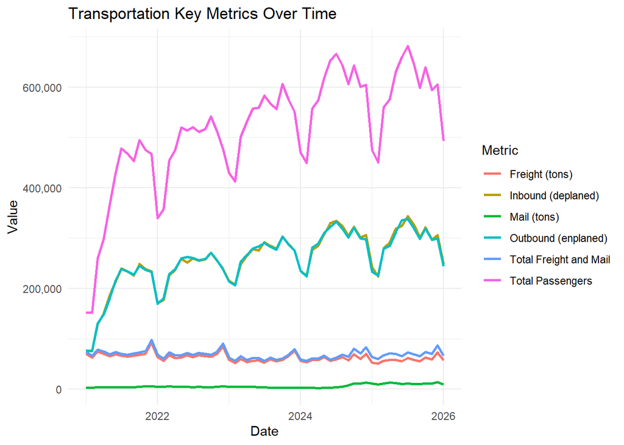

```r
# Chart 1: Overall trends by metric
ggplot(data, aes(x = date, y = value, color = metric)) +
  geom_line(linewidth = 1) +
  labs(
    title = "Transportation Key Metrics Over Time",
    x = "Date",
    y = "Value",
    color = "Metric"
  ) +
  scale_y_continuous(labels = comma) +
  theme_minimal()
```

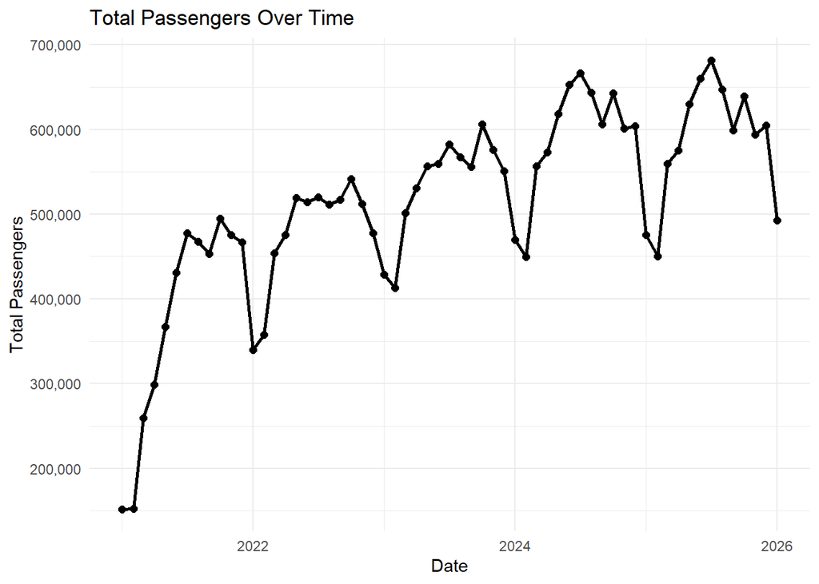

```r
# Chart 2: Total passengers trend
data |>
  filter(metric == "Total Passengers") |>
  ggplot(aes(x = date, y = value)) +
  geom_line(linewidth = 1) +
  geom_point(size = 2) +
  labs(
    title = "Total Passengers Over Time",
    x = "Date",
    y = "Total Passengers"
  ) +
  scale_y_continuous(labels = comma) +
  theme_minimal()
```

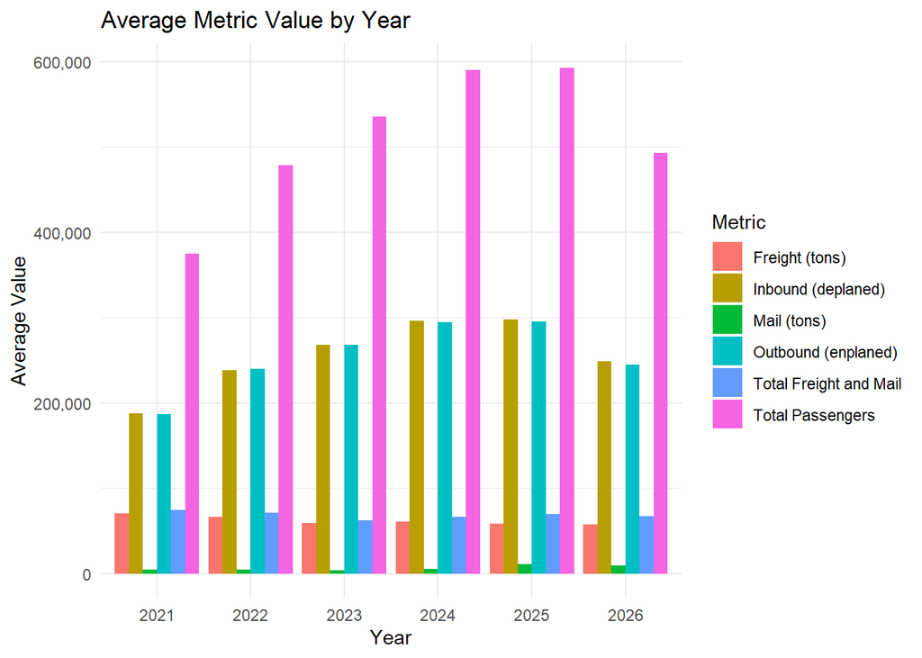

```r
# Chart 3: Average value by year and metric
data |>
  group_by(year, metric) |>
  summarise(avg_value = mean(value, na.rm = TRUE), .groups = "drop") |>
  ggplot(aes(x = year, y = avg_value, fill = metric)) +
  geom_col(position = "dodge") +
  labs(
    title = "Average Metric Value by Year",
    x = "Year",
    y = "Average Value",
    fill = "Metric"
  ) +
  scale_y_continuous(labels = comma) +
  theme_minimal()
```

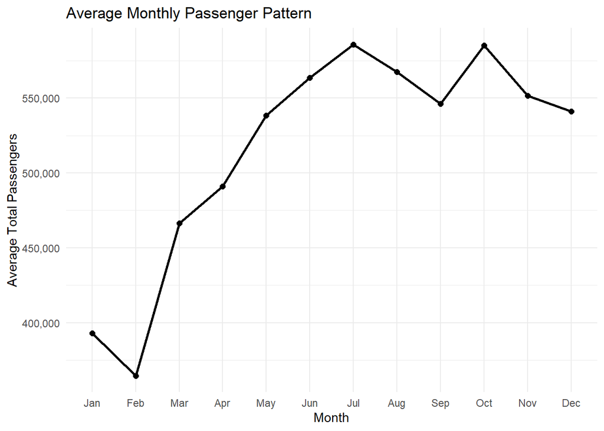

```r
# Chart 4: Monthly pattern for total passengers
data |>
  filter(metric == "Total Passengers") |>
  group_by(month_num, month) |>
  summarise(avg_passengers = mean(value, na.rm = TRUE), .groups = "drop") |>
  arrange(month_num) |>
  ggplot(aes(x = reorder(month, month_num), y = avg_passengers, group = 1)) +
  geom_line(linewidth = 1) +
  geom_point(size = 2) +
  labs(
    title = "Average Monthly Passenger Pattern",
    x = "Month",
    y = "Average Total Passengers"
  ) +
  scale_y_continuous(labels = comma) +
  theme_minimal()
```

## Findings from the Data

The dashboard shows that transportation activity changes over time and that some months have higher values than others. Total passengers appear to be an important indicator because it directly reflects the volume of people using the transportation system.

The yearly comparison helps show whether transportation activity increased or decreased across different years. The monthly pattern also helps identify seasonal changes, which may be useful for planning staffing, service levels, and marketing communication.

## Interpretation of the Dashboard Charts

The first chart compares all available metrics over time and provides a broad overview of transportation performance.

The second chart focuses specifically on total passengers. This chart is useful because passenger volume is one of the clearest ways to understand demand.

The third chart compares average metric values by year. This helps the audience understand whether yearly performance improved or declined.

The fourth chart shows the average monthly passenger pattern. This helps identify months with stronger or weaker passenger activity.

# Project 2: Interactive Shiny App

## Project Description

The second project creates an interactive Shiny application using the same transportation key metrics dataset. The purpose of the app is to allow users to explore transportation trends by selecting different metrics and date ranges.

Unlike the static dashboard, the Shiny app allows the audience to interact with the data. Users can choose which metric they want to analyze, filter the time period, and view trends dynamically.

## Data Description

The Shiny app uses the `pnfs_key_metrics_long.csv` dataset. The app is built around three key fields:

- `date`: used for date filtering
- `metric`: used for selecting different variables
- `value`: used for plotting trends

This structure is appropriate for an interactive dashboard because users can filter by time and choose which metric they want to explore.

https://saurabhparate.shinyapps.io/shiny/